# Sentiment Analysis of Donald Trump’s Inauguration Speech

Regitze Steensgaard

19 March 2025, 14:07:43

## Making the wordcloud readable

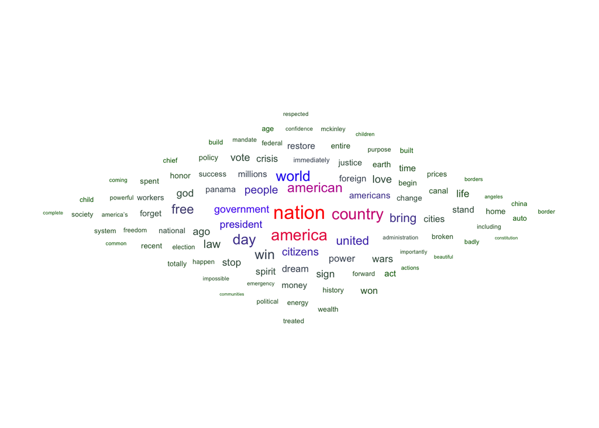

```r
# Jeg gør min wordcloud mere læselig vedhjælp af ggplots funktioner. Derved farves de ord, som anvendes mest.
ggplot(data = trump_top100, aes(label = word, size = n)) +
  geom_text_wordcloud_area(aes(color = n), shape = "diamond") +
  scale_size_area(max_size = 12) +
  scale_color_gradientn(colors = c("darkgreen","blue","red")) +
  theme_minimal()
```

## Sentiment analysis using “afinn” and “nrc”

## Afinn and counting how many words there are in each ranking.

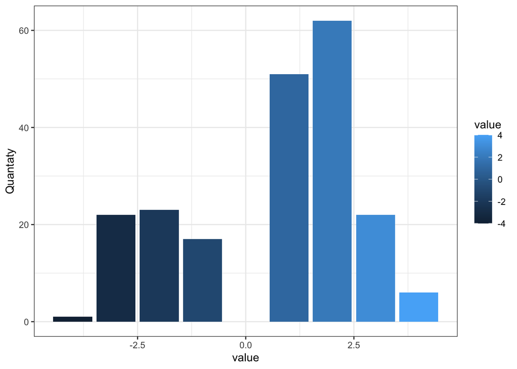

```r
# Jeg udregner antallet af ord i hver ranking
trump_afinn_hist <- trump_afinn %>%
  count(value)

# Indsætter værdierne i et søjlediagram
ggplot(data = trump_afinn_hist, aes(x = value, y = n)) +
  geom_col(aes(fill = value)) +
  ylab("Quantaty")+
  theme_bw()
```

## Counts of words in each feeling-category

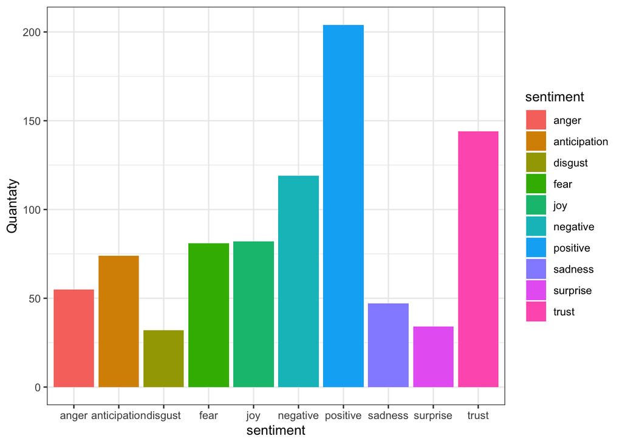

```r
# Jeg udregner, hvor mange ord, som optræder i hver kategori
trump_nrc_n <- trump_nrc %>%
  count(sentiment, sort = TRUE)

# Jeg laver mit diagram over ordene i hver kategori

ggplot(data = trump_nrc_n, aes(x = sentiment, y = n)) +
  geom_col(aes(fill = sentiment))+
  ylab("Quantaty")+
  theme_bw()
```

## A plot over each emotions and words

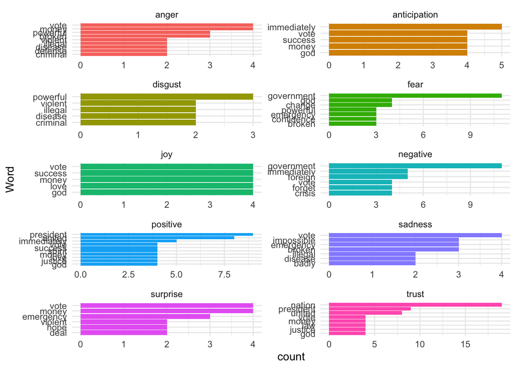

```r
# jeg gruppere ordene efter følelsesregisteret som er lavet i NRC
trump_nrc_n5 <- trump_nrc %>%
  count(word,sentiment, sort = TRUE) %>%
  group_by(sentiment) %>%
  top_n(5) %>%
  ungroup()

# jeg laver diagrammet
trump_nrc_gg <- ggplot(data = trump_nrc_n5, aes(x = reorder(word,n), y = n, fill = sentiment)) +
  geom_col(show.legend = FALSE) +
  facet_wrap(~sentiment, ncol = 2, scales = "free") +
  coord_flip() +
  theme_minimal() +
  labs(x = "Word", y = "count")

# dette vser diagrammet
trump_nrc_gg
```

```r
# denne kode gemmer diagrammet
ggsave(plot = trump_nrc_gg,
       here("figures","trump_nrc_sentiment.png"),
       height = 8,
       width = 5)

# denne graf viser de 5 mest brugte ord indenfor hver "følelse"/sentiment
```

## Final Question

Ved at lave en sentiment-analyse af Donald Trumps tale i ”afinn” og “NRC” får jeg en varieret tilgang til at analysere talens positiv/negativ ladning. Denne fortolknings udgangspunkt er primært “NCR” analysen. Dog vil jeg blot notere, at begge sentiment-analyser viser, at talen er overvejende positiv ladet, men at talen også indeholder en del negative ladninger og følelser i dens ord og forståelse. For at underbygge denne påstand kan jeg anvende min udregning af medianen ud fra “afinn” analysen. Her har ordene fået en værdi fra “-5 til 5”. Beregningen viser, at medianen er 1, dermed er talen langt fra kun positiv, da den er tæt på grænsen til minus, som er negativeladninger.

Endvidere er det vigtigt at være opmærksom på, at man ikke blot kan kategorisere ét ord på en bestemt måde, som er tydeligt i min NCR analyse. Her bliver ordet “vote” registreret ved i alt 8 følelser ud af 10. De to følelses-kategorier, hvor “vote” ikke er registreret, er “fear” og “disgust”. Dette er interessant i forhold til talens tendens og dens ophavssituation. Donald Trump afholder denne tale efter han er blevet indsat som præsident, og derfor har ordet “vote” en central rolle i forhold til, at han er blevet valgt. Dermed er det folket, som netop har stemt/valgt ham, som han sætter i fokus. Det er interessant at se, at “vote” både får fuld score i “surprise” og “anger”. Hvis jeg ser på “vote” i forhold til “surprise”, kan dette referere til, at Trump er overrasket over de stemmer, som han har indhentet. Dette kan være fra etniciteter, som han ikke regnede med ville stemme på ham. Jeg kan ud fra en læsning af talen bekræfte denne antagelse. Når “vote” får et højt match ved “anger”, kan det skildre Trumps tilhørsforhold til dem, som ikke stemte på ham. Sentiment-analysen giver et overblik over Trumps politiske holdninger og reaktioner på at blive præsident. Særligt NRC giver et overblik over, hvordan Trumps holdning til bestemte emner er. Ulempen ved en sentiment-analyse er, at den ikke viser konteksten, hvor ordene optræder. Fx bliver “immediately” matchet med “anticipation”, dette kræver, at man selv skal forstå teksten og konteksten for at kunne forklare, hvorfor det sker. I den sammenhæng skal det forstås som, at Trump har forventninger og agendaer, som skal ske med det samme.

Credit: NRC: Crowdsourcing a Word-Emotion Association Lexicon, Saif Mohammad and Peter Turney, Computational Intelligence, 29 (3), 436-465, 2013.